# Small project

Alessio Assuelli, Wael Gafaiti & Alexandre Monti

## Goal of the project

The goal of this project is to describe and visualize a dataset that we find interesting in order to manage to ask some more general questions related to the data.

After some research, we decided to take data from the website of the Swiss confederation about the number of marriages by cantons and by sex for each year since 1999 until 2021. The dataset can be found at :

https://www.bfs.admin.ch/bfs/en/home/statistics/catalogues-databases/tables.assetdetail.22786904.html

This dataset contains also the number of marriages by age range for each sex and for each year.

For our analysis, we began by creating a CSV file containing the information that we needed because the file provided by the Swiss confederation was not directly usable on R. The CSV file is named “mariages_all.csv” and can be found at the following address :

https://github.com/alex-monti/StatComp-290125/blob/main/mini-project/mariages_all.csv

This dataset is composed of the following variables :

| Variables | Description |
| --- | --- |
| X | Canton or region of Switzerland |
| id | Number assigned to each Canton (useful for the shinyApp) |
| Religions | Predominant religion (0 = Evangelic, 1 = Catholic, 2 = without dominant religion |
| Mariages.x | Number of marriages in year x |
| Population.x | Population in year x |

We recall that the “Region Lémanique” is composed of the Cantons Vaud, Valais and Genève, the “Espace Mittelland” is composed of the Cantons Berne, Fribourg, Soleure, Neuchatel and Jura, the “Suisse du Nord-Ouest” of the Cantons Bâle-ville, Bâle-campagne, Argovie and Zürich, the “Suisse Orientale” of the Cantons Glaris, Schaffhouse, Appenzell Rh.-Int., Appenzell Rh.-Ext., Saint-Gall, Grisons and Thurgovie and the “Suisse Centrale” of the Cantons Lucerne, Uri, Schwytz, Obwald, Nidwald, Zug and Tessin.

As one can see, we added the variable “Population” which was not in the former dataset. This variable is taken from the following dataset which give the population by Canton for each year since 1999 until now :

https://www.bfs.admin.ch/bfs/fr/home/statistiques/catalogues-banques-donnees/tableaux.assetdetail.23064668.html

We also added the variable “Religions” which is taken from the following dataset :

https://www.atlas.bfs.admin.ch/maps/13/fr/15296_108_107_70/24070.html

This dataset provides data for only 2016 to 2018 but we consider that the predominant religion is stable and unchanged since 1999 to 2021.

Now that we have a proper dataset, we would like to describe and visualize them in order to have a better understanding and overview of it.

## Evolution of the number of marriages

Our first question is whether people marry more or less nowadays than before. To this aim, we could just plot the number of marriages in Switzerland over the last two decades, but this would not be really representative because the population has increased since 1999. We then need to take into account the change of population. Thus, we decide to plot the number of marriages per 1000 people (NMTP) over the last two decades.

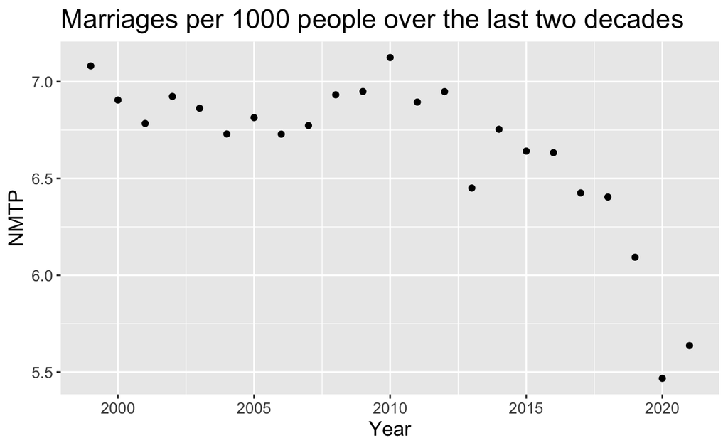

We can see that the NMTP in Switzerland between 1999 and 2006 was pretty constant. It then increased until 2010 where it reached its maximum for the 22 years comparison and then the number of marriages began to decrease more and more. We can observe that the NMTP in 2020 and 2021 were much lower than the mean of the last years but this can be easily explained due to Covid-19. Another interesting point is the NMTP in 2013. Indeed, it seems pretty low in comparison to the NMTP in 2012 and 2014.

The national trend seems decreasing. Now, we would like to know if this trend is the same at a regional and cantonal scale. For that, we create plots which gives the NMTP for each Canton for years 2000, 2010, 2015 and 2020.

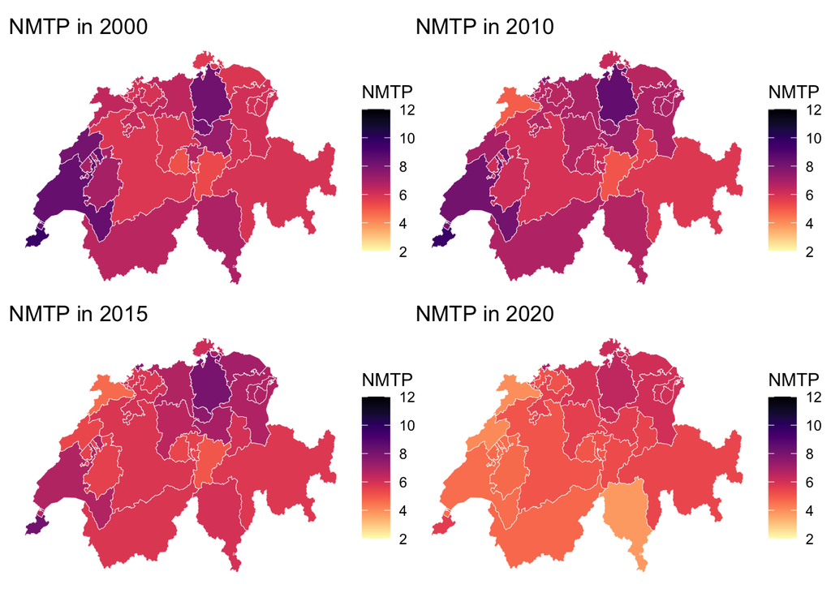

This plot gives us a lot of information. Indeed, it seems that the region “Suisse du Nord-Ouest” remains darker than the other regions over time whereas the region “Suisse Lémanique” becomes clearer. The other regions don’t seem to have clear trend. Let’s find out if our claims are true or if we are just not really good at reading a shinyApp.

#### NMTP by region

To confirm what we claimed, we plot the NMTP over time for each region.

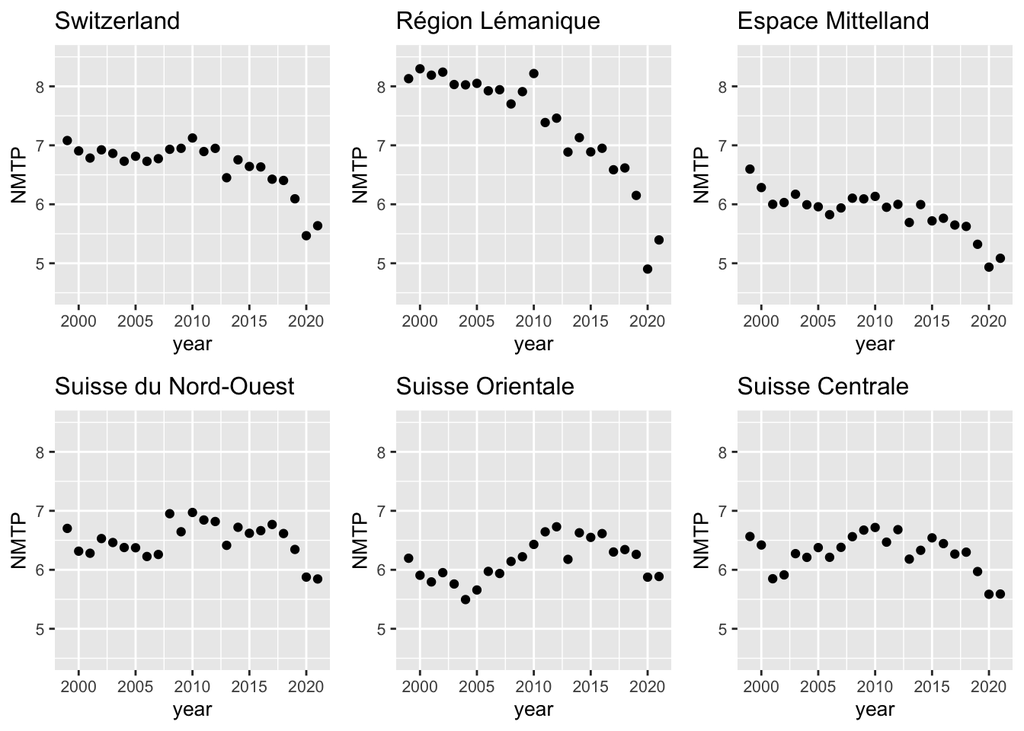

We can see that, indeed, the “Région Lémanique” decreases a lot over the years. On the other hand, the “Suisse du Nord-Ouest” seems pretty constant as we claimed. The “Suisse Orientale” and the “Suisse Centrale” appear to be also constant over time and the “Espace Mittelland” decreases but at a much slower rate than the “Région Lémanique”.

Another interesting remark that can be made is the fact that the “Région Lémanique” had the highest NMTP until 2010 with around 8 marriages per 1000 people whereas all the other regions had at most 6.5-7 marriages per 1000 people which is quite surprising.

#### NMTP by Canton

Now that we have a better idea of the evolution of NMTP for the five large regions of Switzerland, we would like to investigate which Canton has celebrated the most marriages over the last two decades. For this task, we decide to make a mean of NMTP over the years to have the NMTP on average since 1999 to 2021 for each Canton. We can then plot a histogram of our observations :

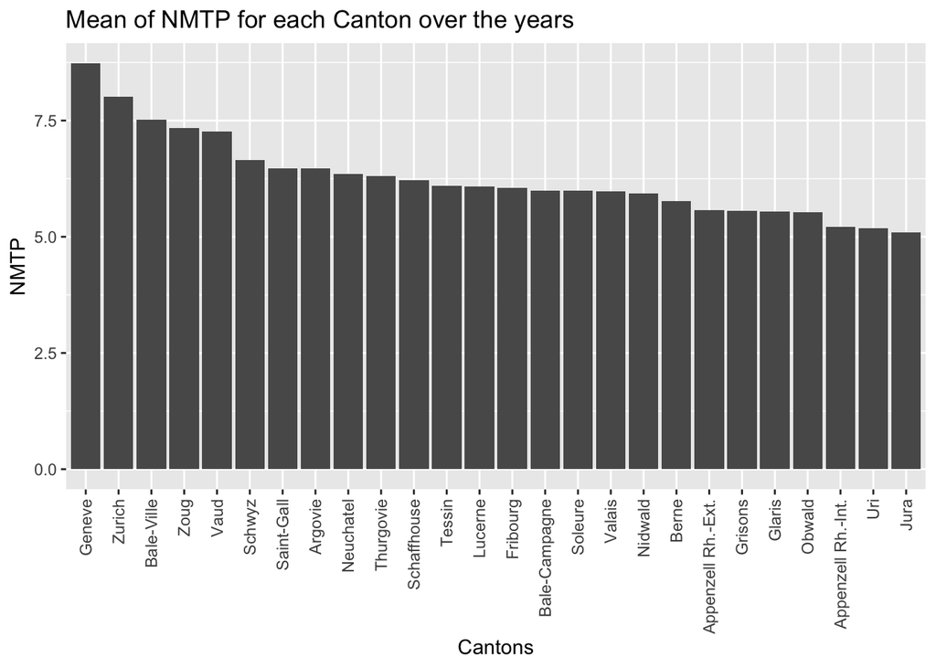

Let’s take a closer look at these five first Cantons. These are Genève, Zürich, Bâle-Ville, Zoug and Vaud. If we remove Vaud from this list, we remark that the four Cantons left are Cantons that are considered as “town” Cantons. But they are also considered as “rich” Cantons and we all know that a marriage is a pretty expensive thing. These considerations rise two questions :

- Is marriage trendy in the cities ?
- Do we need to be rich to marry ?

These two questions are in fact pretty linked as the “town” Cantons are also the ones that have higher life cost in general and thus considered as “rich” and we can see that the other tail of the plot does not reject the hypothesis that we need to be rich to marry as Jura, Uri, the two Appenzells or Grisons have never been considered as “rich” Cantons.

It is easier to find information about the “wealth” of a Canton rather than trends in cities. Thus, to further investigate, we could find data that describe the wealth of a Canton or its people and try to find correlation between these data and our plot.

### NMTP and per-capita GDP

We decide to take the per-capita GDP of each Canton as an indicator of wealth. We found a dataset giving the per-capita GDP for each Canton since 2008 to 2020 at the following link :

https://www.bfs.admin.ch/bfs/fr/home/statistiques/economie-nationale/comptes-nationaux/produit-interieur-brut-canton.assetdetail.23526483.html

We did not find the per-capita GDP data for years 1999 to 2007 so we will only use the marriages data on the period 2008-2020. Even if it is not perfect, it will give us a good overview of the correlation between marriages and per-captia GDP as the per-capita GDP does not vary a lot from year to year.

In order to see if there is a correlation between marriages and per-capita GDP, we plot the NMTP over the period 2008-2020 for each Canton as well as the per-capita GDP over the same period :

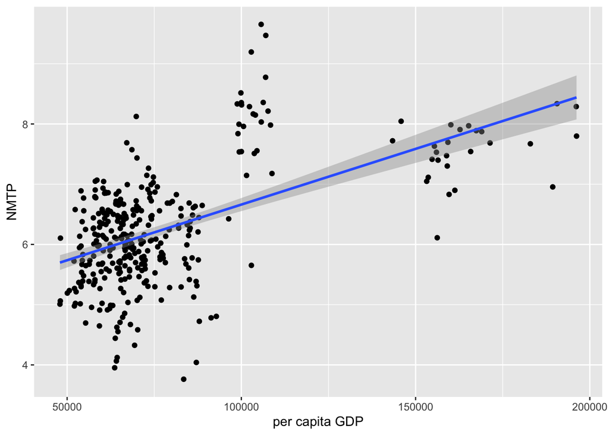

We see that observations tend to have higher NMTP with higher GDP per capita. It can be explained as we told before that it is because marriage is a pretty expensive thing. An important remark to make is that per-capita GDP is not the best indicator of wealth as for example people from Canton Zoug could work in Canton Zürich which would increase the per-capita GDP of Zürich and not from Zoug.

## Religions and marriages

Before the study, we believed in the hypothesis that religions and number of marriages are strongly correlated, since there are obvious links within the latters. Religion has always had a strong place in the swiss society. We can observe that through the number of churches or by reading some extracts of the helvetic Constitution.

In Switzerland, there are three different categories for each canton concerning religion:

- Evangelism dominance
- Catholicism dominance
- No particular dominance

To find a correlation between number of marriages and religion, we plot the number of marriages in 2016 of each canton taking into account the respective religion.

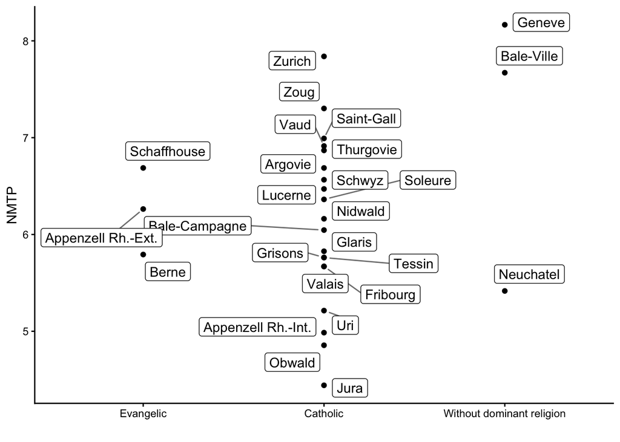

We can immediately observe that the division of the canton’s religion is not uniformly distributed. In fact, catholic cantons represent around 80% of the cantons. Although, we observe that evangelic canton seems to have less marriages than the rest and that there are some catholic cantons who seem to not care about marriage. So, this plot isn’t helping us to draw clear conclusions. Let’s observe the boxplots of the NMTP since 1999 to 2021 hoping for a better visualization of the situation.

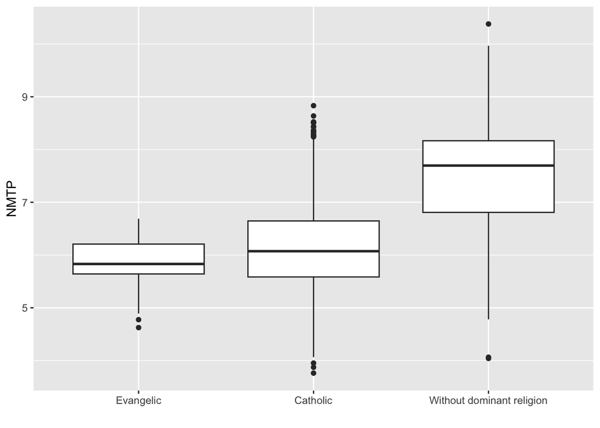

We see that Cantons without dominant religion have a higher NMTP than evangelic and catholic Cantons which goes in the opposite direction as our former hypothesis. Then, with our analysis, we cannot find obvious correlation between predominant religion and marriage but we could increase the quality of our analysis by taking the share of the believing population instead of just the predominant religion for each Canton. Indeed, the Canton Genève is considered without dominant religion, but this does not tell us if there are a lot of believing people in this Canton.

## Age, sex and marriage

As mentioned before, the dataset furnished by the Swiss confederation contains the number of marriages by age range for each sex. We would like to know at what age in general men and women marry in Switzerland. In this context, we create a new CSV file from the former dataset that contains the number of marriages by sex for each year since 1999 to 2021 and for each of the following age range :

- less or equal than 20 years old
- 20 to 24 years old
- 25 to 29 years old
- 30 to 34 years old
- 35 to 39 years old
- 40 to 44 years old
- 45 to 49 years old
- 50 to 54 years old
- 55 to 59 years old
- older or equal than 60 years old

The CSV file can be obtained at the following address :

https://github.com/alex-monti/StatComp-290125/blob/main/mini-project/age1.csv

To compare the age at what men and women marry in Switzerland, we decide to make a mean of the number of marriages by sex for each year. This gives us one observation for each sex and each age range. These observations correspond to the mean number of marriages between 1999 and 2021 for each sex and each age range. We can now plot these observations with a histogram in order to compare at what age men and women marry in Switzerland.

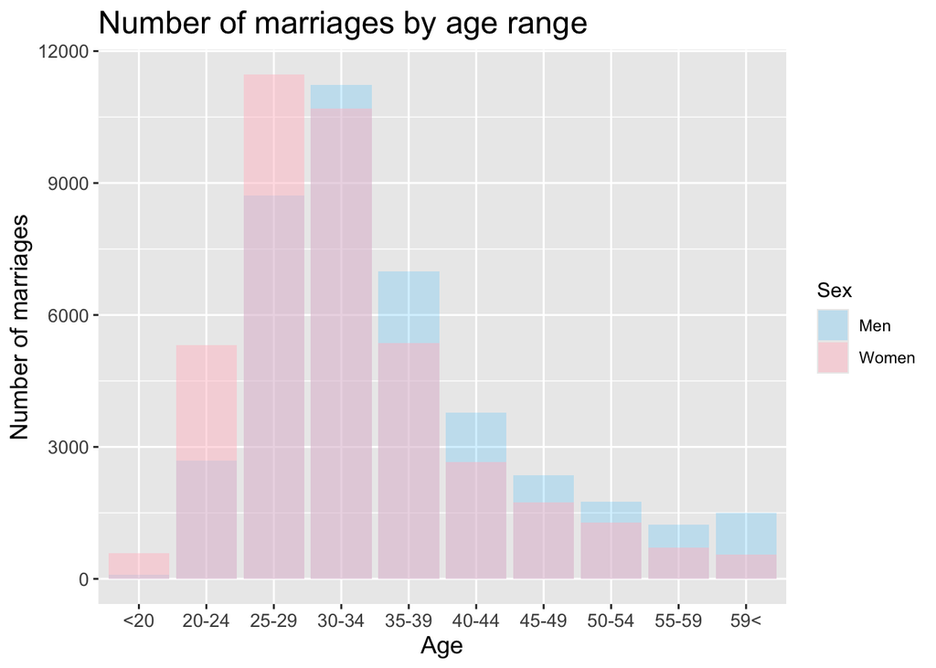

There are many interesting things to say about this plot. First of all, we can see 52% of people marry between 25 and 34 years old which is not really surprising. But we observe a large difference between men and women for the 25-29 years old range. Indeed, there are on average 2500 women more than men who marry between 25 and 29 years old over the last two decades. On the other hand, there are around 500 men more than women who marry between 30 and 34 years old. Overall, 43% of women marry before 30 years old whereas only 29% of men marry before this age

Furthermore, there are always more men than women who marry after 35 years old and on the contrary there are always more women who marry before 25 years old. This fact is clear for people between 20 and 24 years old where there are twice as women (5319) as men (2683) who marry and it is even more apparent for people younger than 20 years old where we have on average 6 times more women (579) than men (94) who marry. The other tail follows the same trend with three times more men (1497) than women (547) who marry after 59 years old.

Thus, we can infer from this plot that women prefer to marry younger than men and men have less problem to marry after 35 years old on average.

## Conclusion

With our study, we can draw interesting conclusions about marriages in Switzerland during the period 1999-2021. Firstly, by analyzing the number of marriages per thousand people (NMTP) on the national scale, we can say that people marry less and less since 2010. This decrease in NMTP is clearly visible on the regional scale, especially for the “Region Lémanique”.

Secondly, by considering the NMTP by Canton, we see that “rich” Cantons marry more than the other Cantons. This correlation is verified when studying the link between per-capita GDP and NMTP even if per-capita GDP is not the best indicator of wealth for Cantons. We could have chosen for example the median salary in each Canton for a better indicator of wealth and thus a better analysis of the relation between wealth and marriage.

Thirdly, we see that there is no strong relationship between predominant religion and NMTP but as already said, the predomiant religion is not really representative of the importance of religion in each Canton. Thus, it is possible to investigate the link between religion and marriage by considering the share of believing population for each Canton.

Finally, we can affirm that more than half of the population marry between 25 and 34 years old. Another interesting fact is that women marry younger than men and men appear to be more open to marry after 35 years old.